# Chapter 5 Homework

### Malaria medication adherence

In `malaria.csv` we have the results from an experiment that provided text alerts to encourage adherence to antimalarial medication (taking the meds) in Ghana. The data are taken from the paper at https://doi.org/10.7910/DVN/M4LY6C (*Raifman, Julia RG, et al. “The impact of text message reminders on adherence to antimalarial treatment in northern Ghana: a randomized trial.” PloS one 9.10 (2014)*).

The `treated` variable is whether or not they get the text alerts, the `adhere` variable is whether they (mostly) adhered to the medication protocol, and the `age` and `male` variables tell us the patient’s age and whether they are male.

**Calculate a 95% interval for the average treatment effect of text reminders on adherence probability.**

```r
d <- read.csv("malaria.csv")
fit1 <- glm( adhere ~ treated, data=d)
( stats1 <- summary(fit1)$coef["treated",] )
```

```
  Estimate Std. Error    t value   Pr(>|t|)
0.07818478 0.04213954 1.85537795 0.06408598
```

```r
# confidence interval
stats1[1] + c(-1,1)*1.96*stats1[2]
```

```
[1] -0.004408725  0.160778282
```

The interval barely overlaps with zero, so this is close but not quite significant at the 0.05 level.

Alternatively, you can bootstrap.

```r
library(parallel)
library(boot)
getATE <- function(data, ind){
  coef(glm(adhere ~ treated, data=data[ind,]))["treated"]
}
set.seed(1)
(boot1 <- boot(d, getATE, 1000,
               parallel="snow", ncpus=detectCores()))
```

```
ORDINARY NONPARAMETRIC BOOTSTRAP


Call:
boot(data = d, statistic = getATE, R = 1000, parallel = "snow",
    ncpus = detectCores())


Bootstrap Statistics :
      original        bias    std. error
t1* 0.07818478 -0.0008982707   0.0429358
```

```r
## percentile bootstrap
quantile(boot1$t, c(.025,.975))
```

```
        2.5%        97.5%
-0.004569818  0.161251186
```

```r
## bias adjusted
quantile(2*boot1$t0 -boot1$t, c(0.025,.975))
```

```
       2.5%       97.5%
-0.00488163  0.16093937
```

Similar results here to the theoretical CI derived from the glm output.

**Do you have any evidence that the treatment selection is driven by the patient’s age or sex?**

This is asking if the age and `male` covariates are predictive of treatment status. Running the regression below indicates that they are not.

```r
summary(glm(treated ~ age*male, data=d))
```

```
Call:
glm(formula = treated ~ age * male, data = d)

Deviance Residuals:
    Min       1Q   Median       3Q      Max
-0.6098  -0.4937   0.4006   0.5051   0.5414

Coefficients:
             Estimate Std. Error t value Pr(>|t|)
(Intercept)  0.448912   0.078978   5.684 2.16e-08 ***
age          0.002090   0.002262   0.924    0.356
male         0.060402   0.116605   0.518    0.605
age:male    -0.002814   0.003329  -0.845    0.398
---
Signif. codes:  0 ‘***’ 0.001 ‘**’ 0.01 ‘*’ 0.05 ‘.’ 0.1 ‘ ’ 1

(Dispersion parameter for gaussian family taken to be 0.2511681)

    Null deviance: 135.75  on 542  degrees of freedom
Residual deviance: 135.38  on 539  degrees of freedom
AIC: 796.73

Number of Fisher Scoring iterations: 2
```

**Break the age into ten year chunks (1-10, 11-20, etc) and estimate a heterogeneous treatment effects model where the treatment effect depends upon age category and sex. What is the 95% CI for the CATE for a 25 year old female?**

First, use `cut` to break the age into chunks.

```r
max(d$age)
```

```
[1] 81
```

```r
d$agegrp <- cut(d$age,10*(0:9))
levels(d$agegrp)
```

```
[1] "(0,10]"  "(10,20]" "(20,30]" "(30,40]" "(40,50]" "(50,60]" "(60,70]" "(70,80]"
[9] "(80,90]"
```

```r
fit2 <- glm(adhere ~ treated*agegrp*male, data=d)

getCATE <- function(data, ind){
  fit <- glm(adhere ~ treated*agegrp*male, data=data[ind,])
  predict(fit, data.frame(treated=1, male=0, agegrp="(20,30]")) -
    predict(fit, data.frame(treated=0, male=0, agegrp="(20,30]"))
  }
set.seed(1)
(boot2 <- boot(d, getCATE, 1000,
               parallel="snow", ncpus=detectCores()))
```

```
prediction from a rank-deficient fit may be misleadingprediction from a rank-deficient fit may be misleading
```

```
ORDINARY NONPARAMETRIC BOOTSTRAP


Call:
boot(data = d, statistic = getCATE, R = 1000, parallel = "snow",
    ncpus = detectCores())


Bootstrap Statistics :
      original      bias    std. error
t1* 0.06265664 0.003767141  0.09104145
```

```r
## percentile bootstrap
quantile(boot2$t, c(.025,.975))
```

```
      2.5%      97.5%
-0.1040539  0.2446065
```

```r
## bias adjusted
quantile(2*boot2$t0 -boot2$t, c(0.025,.975))
```

```
      2.5%      97.5%
-0.1192932  0.2293672
```

Note that the warning is because we include factor levels that are not identified. You can ignore it.

**Simulate data from a regression discontinuity design and recover an estimate of your treatment effect.**

Our simulator has two linear models. The treatment effect at r=0 is 3-1=2 (difference in intercepts)

```r
fcntrl <- function(r){ 1 +10*r + rnorm(length(r), sd=5) }
ftreat <- function(r){ 3 +5*r + rnorm(length(r), sd=5)}
```

Simulate 100 observations centered on r=0, and fit a linear model on either side.

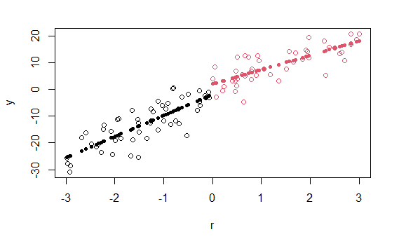

```r
r <- runif(100, -3, 3)
treat <- as.numeric(r>0)
y <- fcntrl(r)*(1-treat) + ftreat(r)*treat
plot(r, y, col=1+(r>0))

rdfit <- glm( y ~ r*treat)
points(r, rdfit$fitted, pch=20, col=1+treat)
```

The CATE at r=0 is

```r
summary(rdfit)
```

```
Call:
glm(formula = y ~ r * treat)

Deviance Residuals:
     Min        1Q    Median        3Q       Max
-11.4883  -2.5660  -0.1568   3.4085   8.7675

Coefficients:
            Estimate Std. Error t value Pr(>|t|)
(Intercept)  -1.8326     1.1666  -1.571   0.1195
r             7.8879     0.7214  10.934   <2e-16 ***
treat         3.8726     1.6511   2.345   0.0211 *
r:treat      -2.5157     1.0244  -2.456   0.0159 *
---
Signif. codes:  0 ‘***’ 0.001 ‘**’ 0.01 ‘*’ 0.05 ‘.’ 0.1 ‘ ’ 1

(Dispersion parameter for gaussian family taken to be 20.07129)

    Null deviance: 17298.9  on 99  degrees of freedom
Residual deviance:  1926.8  on 96  degrees of freedom
AIC: 589.63

Number of Fisher Scoring iterations: 2
```

The true value of 2 should be within 2 standard errors of the true value, 19 times out of 20 when you run this simulator code.